# Challenge_5: Visualizing Time and Space

weekly_challenges

challenge_5

A Holloween Special - Challenge5 Submission

Author

Sai Vineeth Kumar Dara

Published

October 25, 2023

**Make sure you change the author’s name in the above YAML header.**

## Setup

If you have not installed the following packages, please install them before loading them.

```r
library(tidyverse)
library(readr)
library(readxl)
library(haven) #for loading other datafiles (SAS, STATA, SPSS, etc.)

#for plotting time
library(ggplot2) # if you have not installed this package, please install it.
library(lubridate)


#for plotting space
library(sp)
library(sf)
library(maps)
library(rnaturalearth)
library(rnaturalearthdata)
library(gganimate)
library(gifski)

knitr::opts_chunk$set(echo = TRUE, warning=FALSE, message=FALSE)
```

## Challenge Overview

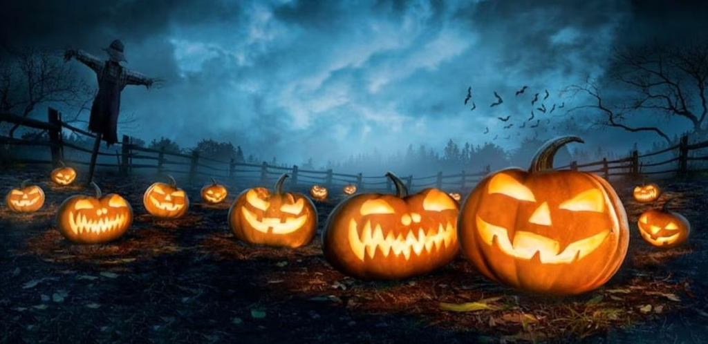

Halloween2023

In this challenge, we will practice the visualization skills learned in the class with two datasets to capture the temporal and spatial patterns of supernatural phenomena.

There will be coding components and writing components. Please read the instructions for each part and complete your challenges.

## Datasets

- Part 1. The UFO Sightings Data (50%)
- Part 2. The Haunted Places Data (50%)

Find the `_data` folder, then read the datasets using the correct R command.

## Part 1. The UFO Sightings Data (50%)

1. **Read and Describe the Data (10%)**

   What is the dimension of the data? What do the columns mean? What is the unit of observation?  
   **Answer:**  
   The dimension of the data is 88875x11.  
   The following are the columns:  
   datetime - the date on which the ufo was sighted  
   city - the city in which the ufo was sighted  
   state- the state in which the ufo was sighted  
   country - the country in which the ufo was sighted  
   shape - the shape of the ufo  
   duration (seconds) - the duration in seconds for which the ufo was sighted  
   duration (hours/min) - the duration in minutes/hours for which the ufo was sighted  
   comments - comments regarding the sighting  
   date posted - the date on which the sighting was posted  
   latitude - latitude location of ufo spotted  
   longitude - longitude location of ufo spotted  
   Here, the unit of observation is a UFO sighting instance. Each row is a case giving information about a ufo sighting e.g., location, duration etc.

   ```r
   #type of your code/command here.
   ufo_data <- read_csv("./challenge5_data/complete_UFO.csv", show_col_types = FALSE)

   ufo_data <- ufo_data %>%
     select(-`...12`)

   dim(ufo_data)
   ```

   ```
   [1] 88875    11
   ```

   ```r
   head(ufo_data)
   ```

   | datetime | city | state | country | shape | duration (seconds) | duration (hours/min) | comments | date posted | latitude | longitude |
   | --- | --- | --- | --- | --- | --- | --- | --- | --- | --- | --- |
   | 11/11/1906 | wien (austria) | NA | NA | other | 10800 | 3 h | The oldest professional photo of a UFO object is from Wien observatory&#44 in 1906&#33 | 12/23/2002 | 48.208174 | 16.373819 |
   | 1/2/1910 | kirksville (near) | mo | us | disk | 120 | minutes | Historical sighting (1903 - 1913) Northern Missouri | 9/15/2005 | 40.1947222 | -92.583056 |
   | 5/28/1910 | solon | me | us | unknown | 0 | don&#39t know | entry in my great-grandmother&#39s diary&#44date 28 may 1910&#44refers to watching the comet zig-zaging in the sky&#44 followed by a zig-zag diagra | 12/5/2001 | 44.9494444 | -69.858889 |
   | 6/1/1910 | wills point | tx | us | cigar | 120 | 2 minutes | Cigar shaped object moving from West to East | 4/16/2005 | 32.7091667 | -96.008056 |
   | 9/15/1914 | meeting lake (canada) | ab | NA | unknown | 0 | NA | Night flying &quot;airplane&quot; with search lights observed on several occasions near Meeting Lake&#44 Alberta in late 1914. | 2/1/2007 | 55.170828 | -118.837956 |
   | 4/5/1916 | france (above; from aircraft) | NA | NA | cigar | 60 | about 1 min. | ((NUFORC Note: Possible hoax. PD)) Saw 3 cigar shaped crafts. | 3/9/2004 | 46.227638 | 2.213749 |

   ```r
   colnames(ufo_data)
   ```

   ```
    [1] "datetime"             "city"                 "state"
    [4] "country"              "shape"                "duration (seconds)"
    [7] "duration (hours/min)" "comments"             "date posted"
   [10] "latitude"             "longitude"
   ```

2. Please plot a temporal/time-series graph to present the following patterns. **You may need to subset or mutate the data for graphing.**

   (1) the total number of UFO sighting reports over the years (date_break = year). **(15%)**

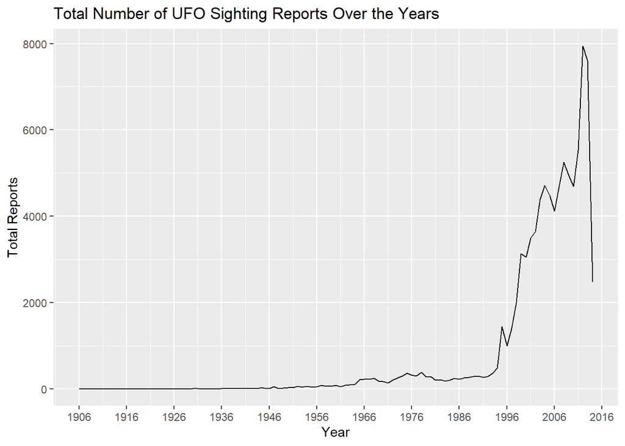

   ```r
   #change the datetime column to Date class
   ufo_data$datetime <- as.Date(ufo_data$datetime, format = "%m/%d/%Y")

   # Create a time series for the total number of sightings over the years
   ufo_year_data <- ufo_data %>%
     group_by(year = lubridate::year(datetime)) %>%
     summarize(total_reports = n())

   # Create the plot -  we can change the number of years shown by changing the scale
   ggplot(ufo_year_data, aes(x = year, y = total_reports)) +
     geom_line() +
     labs(title = "Total Number of UFO Sighting Reports Over the Years", x = "Year", y = "Total Reports") +
     scale_x_continuous(breaks = seq(min(ufo_year_data$year), max(ufo_year_data$year)+10, by = 10 ))
   ```

   ```r
     #theme(axis.text.x = element_text(angle = -90, hjust = 1))
   ```

   (2) the total number of UFO sighting reports by months between 2010-01-01 and 2014-01-01. **(15%)**

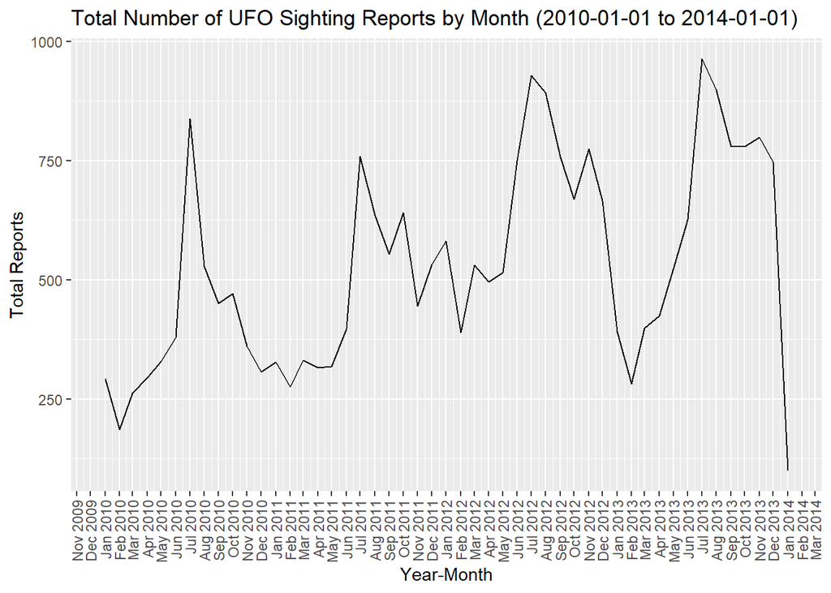

   ```r
   #UFO sighting reports by months between 2010-01-01 and 2014-01-01.
   ufo_month_data <- ufo_data %>%
     filter(datetime >= as.Date('2010-01-01') & datetime <= as.Date('2014-01-01')) %>%
     group_by(monthyear = floor_date(datetime, "month")) %>%
     summarize(total_reports = n())


   # Plotting the monthly data for the specified period
   ggplot(ufo_month_data, aes(x = monthyear, y = total_reports)) +
     geom_line() +
     scale_x_date(date_breaks = "1 month", date_labels = "%b %Y") +
     theme(axis.text.x = element_text(angle = 90, hjust = 1, vjust = 0.5)) +
         labs(title = "Total Number of UFO Sighting Reports by Month (2010-01-01 to 2014-01-01)", x = "Year-Month", y = "Total Reports")
   ```

[figure not shown]

   ```r
   #yearly plot
   ufo_yearly_plot_animated <- ggplot(ufo_year_data, aes(x = year, y = total_reports)) +
     geom_line() +
     geom_point() +
     labs(title = "Total Number of UFO Sighting Reports Over the Years", x = "Year", y = "Total Reports") +
     scale_x_continuous(breaks = seq(min(ufo_year_data$year), max(ufo_year_data$year)+10, by = 10 )) +
     transition_reveal(year)

   animate(ufo_yearly_plot_animated, duration = 20, fps = 10, width = 500, height = 500, renderer = gifski_renderer())
   ```

   ```r
   anim_save("UFOYearlyPlot.gif")
   ```

5. **(Optional)** Suppose we are interested in describing the country variations in types and numbers of UFO sighting reports. How can we use bar plots to visualize the difference across countries (using the *country* column, you can recode the empty cells with “others”)? **Note that you may need to do the data transformation or mutation needed to help graphing.**

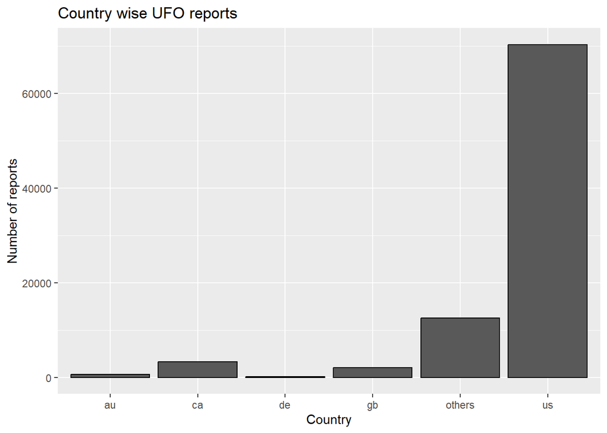

   ```r
   #type of your code/command here.
   ufo_data_mod <- ufo_data %>%
       mutate(country = ifelse(is.na(country), "others", country))


   ufo_country_totals <- ufo_data_mod %>%
     group_by(country) %>%
     summarise(total_reports = n())
   ggplot(data = ufo_country_totals, aes(x = factor(country), y = total_reports)) +
         geom_bar(stat = "identity", color = "black", na.rm = TRUE) +
         labs(title = "Country wise UFO reports", x = "Country", y = "Number of reports")
   ```

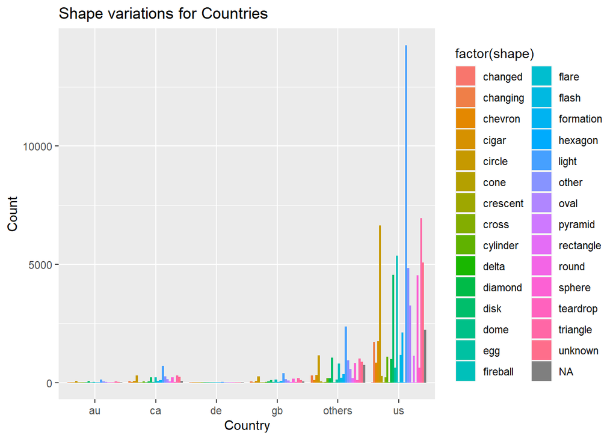

   ```r
   ggplot(ufo_data_mod, aes(x=factor(country), fill=factor(shape))) +
         geom_bar(position="dodge") +
         labs(title="Shape variations for Countries", x="Country", y="Count")
   ```

## Part 2. The Haunted Places Data (50%)

This data contains the reports of haunted places in the United States. The dataset was compiled by Tim Renner, using The Shadowlands Haunted Places Index, and shared on data.world. You can learn more about this data by checking: https://www.kaggle.com/datasets/sujaykapadnis/haunted-places

1. **Read and Describe the Data (10%) (Note: you don’t need to remove the empty rows after the first row; `read_csv()` should automatically remove them).**

   What is the dimension of the data? What do the columns mean? What is the unit of observation?  
   **Answer:**  
   The dimension of the data is 10992x10. There are 10992 rows and 10 columns.  
   The columns present in the data are the following:  
   city - The city where the place is located.  
   country - The country where the place is located (always “United States”)  
   description - A text description of the place.  
   location - A title for the haunted place.  
   state - The US state where the place is located.  
   state_abbrev - The two-letter abbreviation for the state.  
   longitude - Longitude of the place.  
   latitude - Latitude of the place.  
   city_longitude - Longitude of the city center.  
   city_latitude - Latitude of the city center.

   The unit of observation here is a haunted place. Each row is a case and gives us information about the haunted place e.g., location.

   ```r
   #reading data
   haunted_places <- read_csv("./challenge5_data/haunted_places.csv", show_col_types = FALSE)

   dim(haunted_places)
   ```

   ```
   [1] 10992    10
   ```

   ```r
   head(haunted_places)
   ```

   | city | country | description | location | state | state_abbrev | longitude | latitude | city_longitude | city_latitude |
   | --- | --- | --- | --- | --- | --- | --- | --- | --- | --- |
   | Ada | United States | Ada witch - Sometimes you can see a misty blue figure floating within a 3-mile radius of the Ada Cemetery on 2 Mile between Egypt Valley and Honey Creek. The story of her origin is as follows: A man s… | Ada Cemetery | Michigan | MI | -85.50489 | 42.96211 | -85.49548 | 42.96073 |
   | Addison | United States | A little girl was killed suddenly while waiting for a school bus by a speeding car. Since her death things have happened. The day of her funeral she started knocking on doors of the house she was born… | North Adams Rd. | Michigan | MI | -84.38184 | 41.97142 | -84.34717 | 41.98643 |
   | Adrian | United States | If you take Gorman Rd. west towards Sand Creek, you will come to a gravel road leading north. A mile or so up this road you will come to narrow one lane trestle bridge. The road goes under this. Legen… | Ghost Trestle | Michigan | MI | -84.03566 | 41.90454 | -84.03717 | 41.89755 |
   | Adrian | United States | In the 1970's, one room, room 211, in the old section of the dorms exhibited several phenomena. Don't know if this still continues today. The door into the room from the hallway, as well as the door i… | Siena Heights University | Michigan | MI | -84.01757 | 41.90571 | -84.03717 | 41.89755 |
   | Albion | United States | Kappa Delta Sorority - The Kappa Delta Sorority is haunted by an entity simply known as 'P'. It is said she was a sister there who died in a car accident. Current sisters there have reported hearing g… | Albion College | Michigan | MI | -84.74518 | 42.24401 | -84.75303 | 42.24310 |
   | Albion | United States | A mysterious lady in white has been spotted in this cemetery. | Riverside Cemetery | Michigan | MI | -84.75306 | 42.23681 | -84.75303 | 42.24310 |

   ```r
   colnames(haunted_places)
   ```

   ```
    [1] "city"           "country"        "description"    "location"
    [5] "state"          "state_abbrev"   "longitude"      "latitude"
    [9] "city_longitude" "city_latitude"
   ```

2. Plot a USA map with states boundaries. There are multiple ways of plotting this map. **(15%)**

   You can use the `geom_polygon()` (which requires a data of spatial coordinates for plotting a polygon), or you can use `geom_sf()` (which requires a shapefile of the US). Please refer to the examples in the Week#8 demo file.

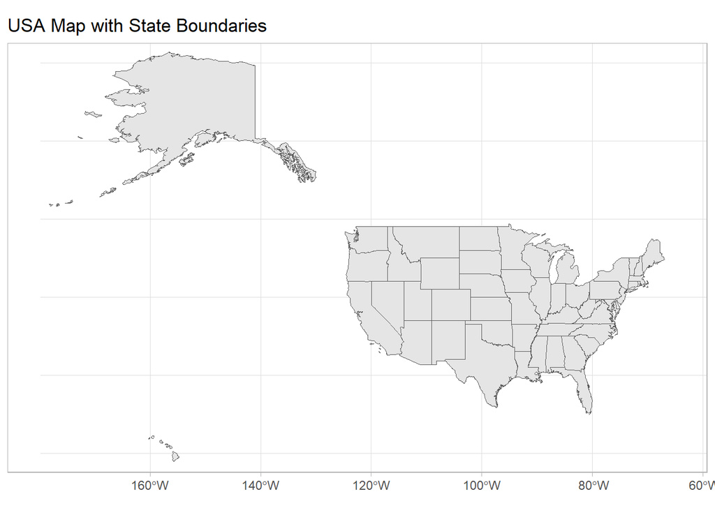

   ```r
   states_sf<-st_read("./challenge5_data/States_shapefile.shp")
   usa_map<-ggplot()+
     geom_sf(data = states_sf)+
     coord_sf(xlim = c(-180, -65), ylim = c(20, 70))+
     theme_light() +
     labs(title = "USA Map with State Boundaries")

   print(usa_map)
   ```

3. Plot the haunted places using the *city_longtitude* and *city_latitude* with `geom_point()` on the USA map generated above. **(15%)**

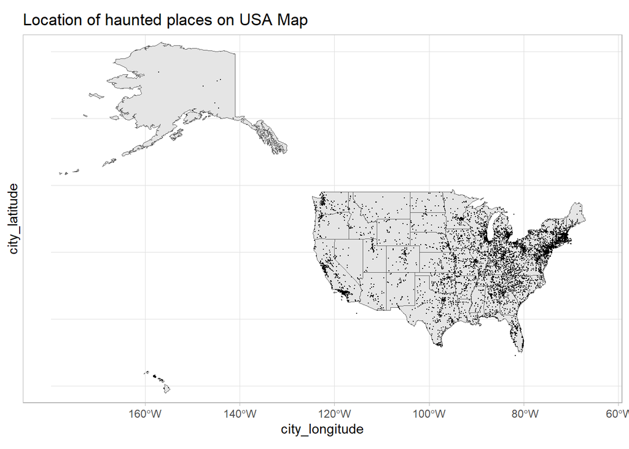

   ```r
   #type of your code/command here.
   haunted_places_map<-ggplot()+
     geom_sf(data = states_sf)+
     geom_point(data = haunted_places, aes(x = city_longitude, y = city_latitude), pch = 19, size=0.00005, na.rm = TRUE )+
     coord_sf(xlim = c(-180, -65), ylim = c(20, 70)) +
     theme_light() +
     labs(title = "Location of haunted places on USA Map")

   print(haunted_places_map)
   ```

4. Please write a paragraph describing the pattern of the haunted spaces you find on the map above. (10%)  
   Answer:  
   We can observe from the above plot that the Eastern part of USA has more haunted places than the Western plot. States wise, California has the highest number of haunted places and Washington DC has the lowest number of haunted places. And there seems to be more density of haunted places near the coastal regions.

   ```r
   #type of your code/command here.
   haunted_places %>%
     group_by(state) %>%
     summarise(Number_of_places = n()) %>%
     arrange(desc(Number_of_places))
   ```

   | state | Number_of_places |
   | --- | --- |
   | California | 1070 |
   | Texas | 696 |
   | Pennsylvania | 649 |
   | Michigan | 529 |
   | Ohio | 477 |
   | New York | 459 |
   | Illinois | 395 |
   | Kentucky | 370 |
   | Indiana | 351 |
   | Massachusetts | 342 |

   [output cut: 41 more lines]